# Use the R-multimode package on the data of Lydia

This document presents the various modules of the Multimode package of R. A complete presentation of the package can be found on the [documentation](https://cran.r-project.org/web/packages/multimode/multimode.pdf).

```r
library(multimode)
library(mclust)
```

# Gaussian mixture

This part of the code generates a sample from a Gaussian mixture.

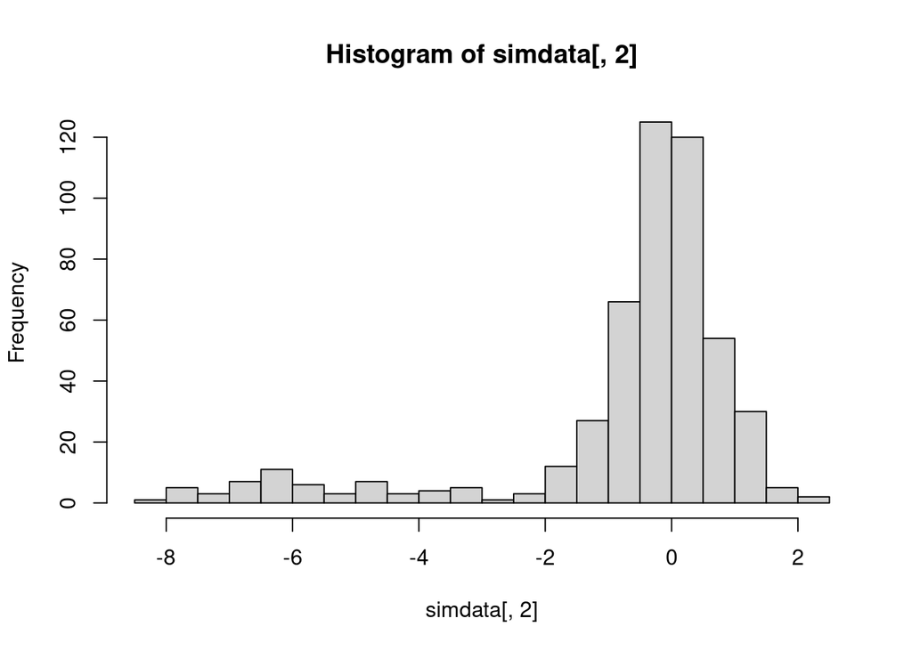

```r
size <- 500

simdata = sim(modelName = "V",
              parameters = list(pro = c(0.85, 0.15),
                                mean = c(0, -5),
                                variance = list(modelName = "V",
                                                d = 1,
                                                G = 2,
                                                sigmasq = c(0.5, 3))),
              n = size)
#plot(scale(simdata[,2]), type = "h")
hist(simdata[,2], breaks=20)
```

## Several test for multimodality

### We use the Mclust package on this dataset to fit with gaussian mixture.

mclust is a contributed R package for model-based clustering, classification, and density estimation based on finite normal mixture modelling. It provides functions for parameter estimation via the EM algorithm for normal mixture models with a variety of covariance structures, and functions for simulation from these models. A complete presentation of the package can be found on the [documentation](https://cran.r-project.org/web/packages/mclust/vignettes/mclust.html).

> Here, we estimate the model parameters on the assumption that there are two peaks. This is reflected in the choice of parameter $G = 2$ in the code.

```r
simdata.gmm = Mclust(simdata, G=2)
summary(simdata.gmm)
```

```
## ----------------------------------------------------
## Gaussian finite mixture model fitted by EM algorithm
## ----------------------------------------------------
##
## Mclust VII (spherical, varying volume) model with 2 components:
##
##  log-likelihood   n df       BIC       ICL
##       -1015.816 500  7 -2075.135 -2080.001
##
## Clustering table:
##   1   2
##  62 438
```

```r
#simdata.gmm$parameters
simdata.gmm$parameters$pro
```

```
## [1] 0.12493 0.87507
```

```r
simdata.gmm$parameters$mean
```

```
##            [,1]        [,2]
## group  1.966008  1.00379018
## 1     -5.233941 -0.02415667
```

```r
simdata.gmm$parameters$variance$sigmasq
```

```
## [1] 1.4972441 0.2473955
```

```r
#simdata2.gmm = Mclust(simdata, G=2)
#summary(simdata2.gmm)
#simdata2.gmm$parameters
```

### Multimode Package

In this section, we try out the different methods of the multimode package.

- The Ameijeras-Alonso test
- The Silverman test
- The Dip test
- The excess mass test

We try to localize the mod the the function **locmode** of this package.

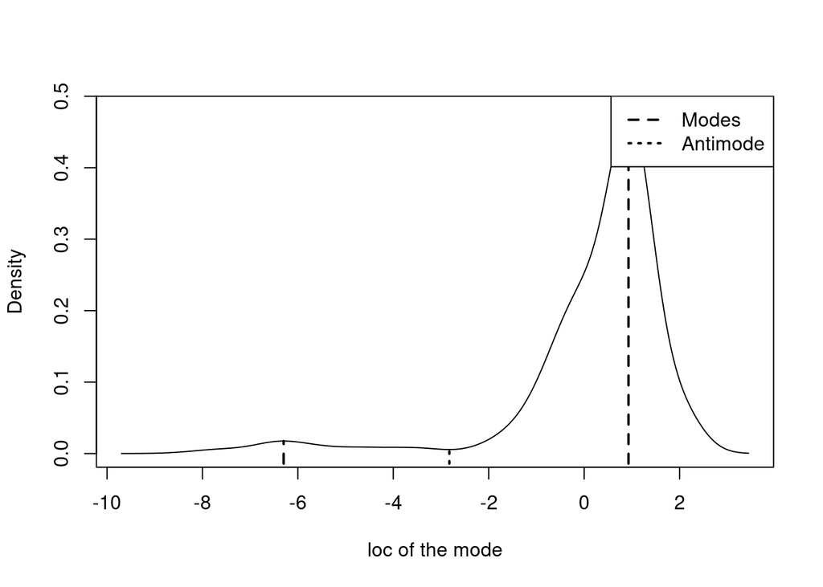

```
##
## Estimated location
## Modes: -6.297944  0.9298194
## Antimode: -2.825441
##
## Estimated value of the density
## Modes: 0.01745221  0.4807955
## Antimode: 0.005596406
##
## Critical bandwidth: 0.4603424
```

```r
# Kernel density estimation with two modes
locmodes(simdata,mod0=2,display=TRUE,xlab="loc of the mode")
```

#### Ameijeiras-Alonso ACR

```r
modetest(simdata,mod0=1,method="ACR",B=5,n=NULL,tol=NULL)
```

```
##
##  Ameijeiras-Alonso et al. (2019) excess mass test
##
## data:  simdata
## Excess mass = 0.061998, p-value < 2.2e-16
## alternative hypothesis: true number of modes is greater than 1
```

#### Silverman

```r
modetest(simdata,mod0=1,method="SI",B=5,submethod=NULL,n=NULL,tol=NULL)
```

```
##
##  Silverman (1981) critical bandwidth test
##
## data:  simdata
## Critical bandwidth = 1.4386, p-value < 2.2e-16
## alternative hypothesis: true number of modes is greater than 1
```

```r
modetest(simdata,mod0=1,method="SI",B=5,submethod=1,n=NULL,tol=NULL)
```

```
##
##  Silverman (1981) critical bandwidth test
##
## data:  simdata
## Critical bandwidth = 1.4386, p-value < 2.2e-16
## alternative hypothesis: true number of modes is greater than 1
```

#### The Dip Test (HH)

```r
modetest(simdata,mod0=1,method="HH",B=5,n=NULL,tol=NULL)
```

```
##
##  Hartigan and Hartigan (1985) dip test
##
## data:  simdata
## Dip = 0.030999, p-value < 2.2e-16
## alternative hypothesis: true number of modes is greater than 1
```

#### The Excess Mass test (FM)

```r
modetest(simdata,mod0=1,method="FM",B=5,n=NULL,tol=NULL)
```

```
##
##  Fisher and Marron (2001) Cramer-von Mises test
##
## data:  simdata
## Cramer-von Mises = 17.418, p-value < 2.2e-16
## alternative hypothesis: true number of modes is greater than 1
```

# Simulate a compound Poisson processes

This code simulate the Poisson processes at each observations

Choose a random distribution

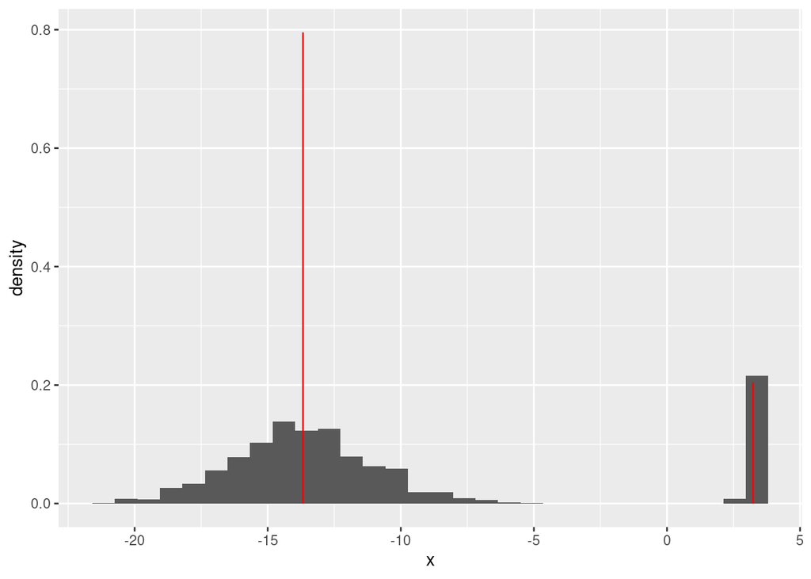

```r
K <- 2
pi_raw <- rexp(K)
theta <- list(pi = pi_raw/sum(pi_raw),
             mu = rnorm(K, 0, 10),
             sigma = abs(rnorm(K, 0, 3)))

rnormmix <- function(n,theta){
  y <-apply(rmultinom(n, size = 1, prob = theta$pi),2,function(col) which(col==1))
  # generate sample
  return(data.frame(x=rnorm(n, theta$mu[y], theta$sigma[y]),y=y))
}

df <- rnormmix(1000, theta)
library(ggplot2)
ggplot(data=df, aes(x=x)) + geom_histogram(aes(y=..density..)) +
  geom_segment(data=data.frame(x=theta$mu, yend=theta$pi),
               aes(x=x,xend=x,y=0,yend=yend), color="red")
```

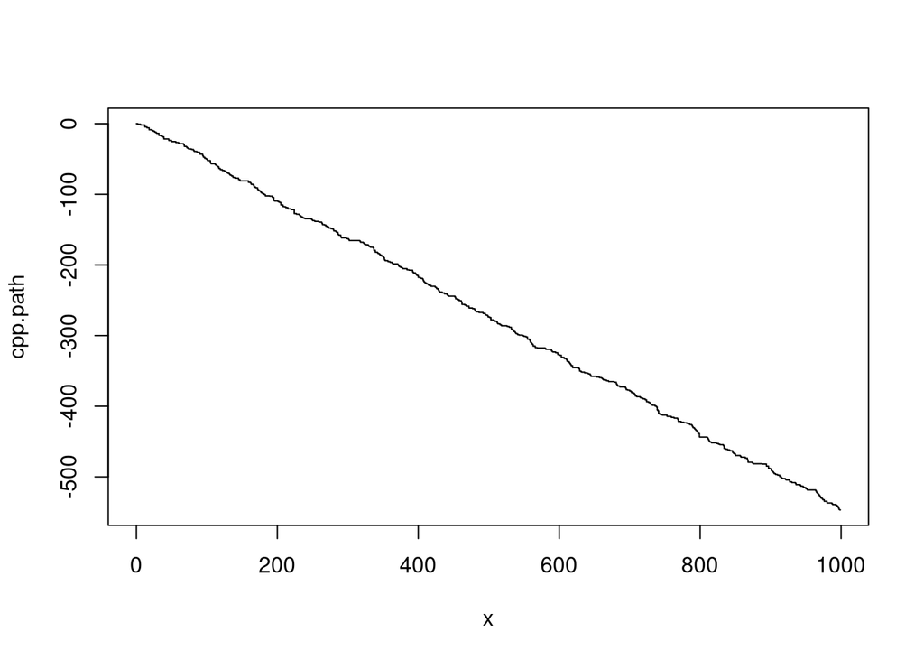

```r
rhosGen <- function(lambda, maxTime){
  rhos <- NULL
  i <- 1
  while(sum(rhos) < maxTime){
    samp <- rexp(n = 1, rate = lambda)
    rhos[i] <- samp
    i <- i+1
  }
  return(head(rhos, -1))
}
taosGen <- function(lambda, maxTime){
  rhos <- rhosGen(lambda, maxTime)
  taos <- NULL
  cumSum <- 0
  for(i in 1:length(rhos)){
    taos[i] <- sum(rhos[1:i])
  }
  return(taos)
}
ppGen <- function(lambda, maxTime){
  taos <- taosGen(lambda, maxTime)
  pp <- NULL
  ppjump <- NULL
  data <- NULL
  jump <- NULL
  for(i in 1:maxTime){
    pp[i] <- sum(taos <= i)
    df <- rnormmix(pp[i], theta)
    jump[i] <- sum(rnorm(pp[i]-pp[i-1], -1.1, 0.3))
    data[i] <- sum(jump[0:i])
  }
  return(list(data, jump))
}
size <- 1000
cpp <- ppGen(0.5, size)
cpp.path <- cpp[[1]]
cpp.jump <- cpp[[2]]
x <- seq(0, size-1, by=1)

#par(mfrow=c(2,1))
plot(x,cpp.path, type="s")
```

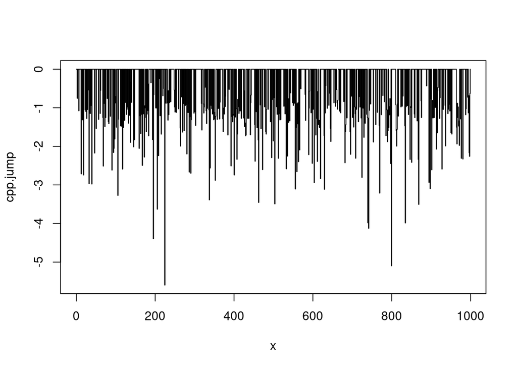

```r
plot(x,cpp.jump, type="s")
```

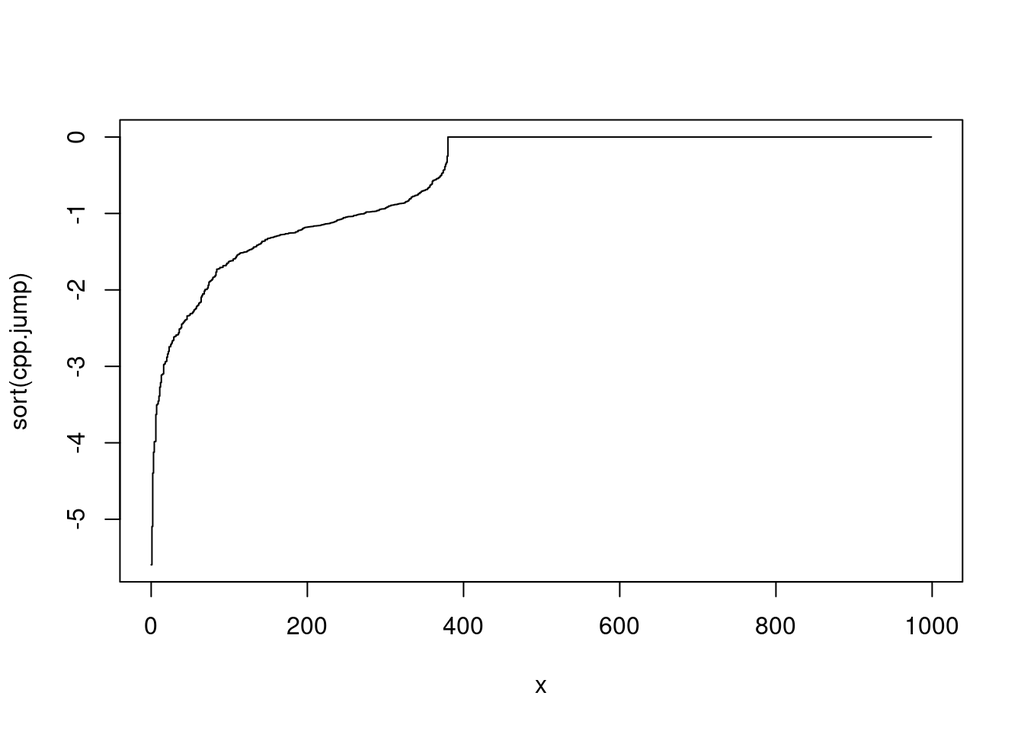

```r
plot(x,sort(cpp.jump), type="s")
```

Draw the histogram of the jump.

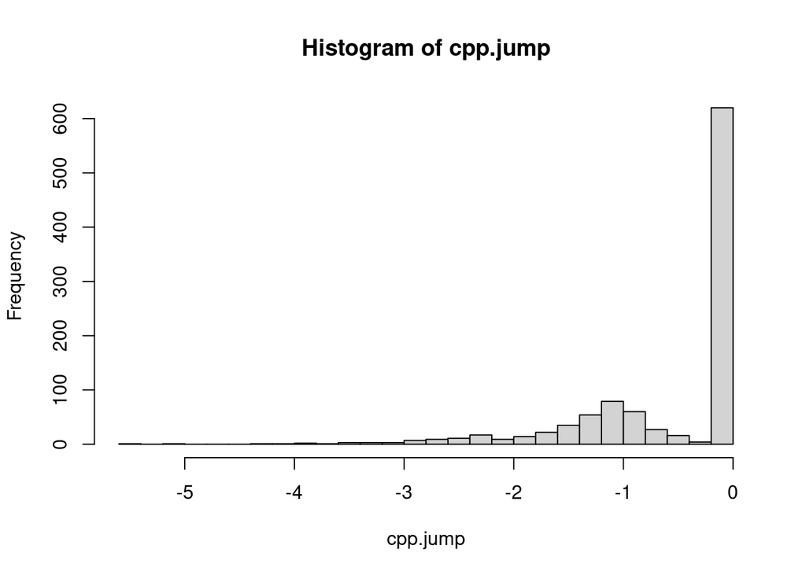

```r
hist(cpp.jump, breaks=20)
```

### Now lets fit a Gaussian finite mixture model with the Mclust package.

```r
cpp.jump.gmm = Mclust(cpp.jump, G=2)
summary(cpp.jump.gmm)
```

```
## ----------------------------------------------------
## Gaussian finite mixture model fitted by EM algorithm
## ----------------------------------------------------
##
## Mclust E (univariate, equal variance) model with 2 components:
##
##  log-likelihood    n df       BIC       ICL
##       -1108.916 1000  4 -2245.462 -2311.843
##
## Clustering table:
##   1   2
##  92 908
```

```r
cpp.jump.gmm$parameters
```

```
## $pro
## [1] 0.1042997 0.8957003
##
## $mean
##          1          2
## -2.3730759 -0.3341819
##
## $variance
## $variance$modelName
## [1] "E"
##
## $variance$d
## [1] 1
##
## $variance$G
## [1] 2
##
## $variance$sigmasq
## [1] 0.3177483
```

### Multimode Package

We try to localize the mod

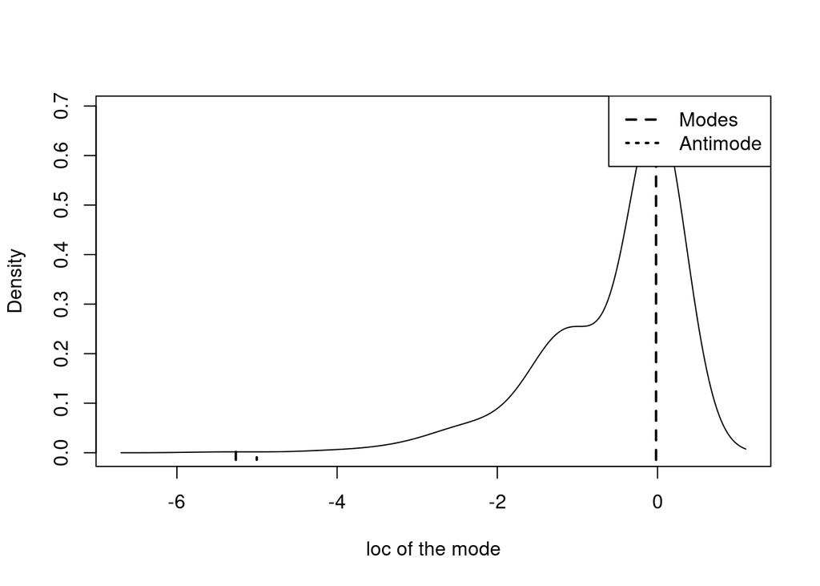

```
##
## Estimated location
## Modes: -5.264296  -0.01821428
## Antimode: -5.003194
##
## Estimated value of the density
## Modes: 0.00178041  0.6922739
## Antimode: 0.001735302
##
## Critical bandwidth: 0.3672943
```

```r
# Kernel density estimation with two modes
locmodes(cpp.jump,mod0=2,display=TRUE,xlab="loc of the mode")
```

#### Ameijeiras-Alonso ACR

```r
#modetest(cpp.jump,mod0=1,method="ACR",B=5,n=NULL,tol=NULL)
```

#### Silverman

```r
modetest(cpp.jump,mod0=2,method="SI",B=5,submethod=NULL,n=NULL,tol=NULL)
```

```
##
##  Silverman (1981) critical bandwidth test
##
## data:  cpp.jump
## Critical bandwidth = 0.36705, p-value < 2.2e-16
## alternative hypothesis: true number of modes is greater than 2
```

```r
modetest(cpp.jump,mod0=2,method="SI",B=5,submethod=1,n=NULL,tol=NULL)
```

```
##
##  Silverman (1981) critical bandwidth test
##
## data:  cpp.jump
## Critical bandwidth = 0.36705, p-value = 0.2
## alternative hypothesis: true number of modes is greater than 2
```

#### The Dip Test (HH)

```r
#modetest(cpp.jump,mod0=1,method="HH",B=5,n=NULL,tol=NULL)
```

#### The Excess Mass test (FM)

```r
modetest(cpp.jump,mod0=2,method="FM",B=5,n=NULL,tol=NULL)
```

```
##
##  Fisher and Marron (2001) Cramer-von Mises test
##
## data:  cpp.jump
## Cramer-von Mises = 20.102, p-value < 2.2e-16
## alternative hypothesis: true number of modes is greater than 2
```

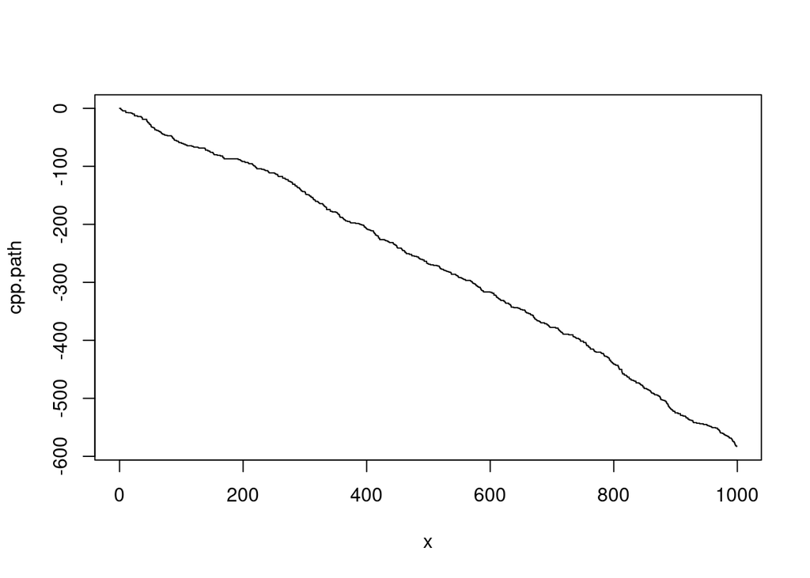

```r
rhosGen <- function(lambda, maxTime){
  rhos <- NULL
  i <- 1
  while(sum(rhos) < maxTime){
    samp <- rexp(n = 1, rate = lambda)
    rhos[i] <- samp
    i <- i+1
  }
  return(head(rhos, -1))
}
taosGen <- function(lambda, maxTime){
  rhos <- rhosGen(lambda, maxTime)
  taos <- NULL
  cumSum <- 0
  for(i in 1:length(rhos)){
    taos[i] <- sum(rhos[1:i])
  }
  return(taos)
}
ppGen <- function(lambda, maxTime){
  taos <- taosGen(lambda, maxTime)
  pp <- NULL
  ppjump <- NULL
  data <- NULL
  jump <- NULL
  for(i in 1:maxTime){
    pp[i] <- sum(taos <= i)
    df <- rnormmix(pp[i], theta)
    jump[i] <- sum(rnorm(pp[i]-pp[i-1], -1.1, 0.3))
    data[i] <- sum(jump[0:i])
  }
  return(list(data, jump))
}
size <- 1000
cpp <- ppGen(0.5, size)
cpp.path <- cpp[[1]]
cpp.jump <- cpp[[2]]
x <- seq(0, size-1, by=1)

#par(mfrow=c(2,1))
plot(x,cpp.path, type="s")
```

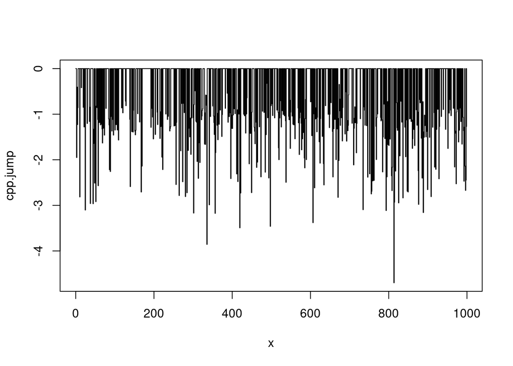

```r
plot(x,cpp.jump, type="s")
```

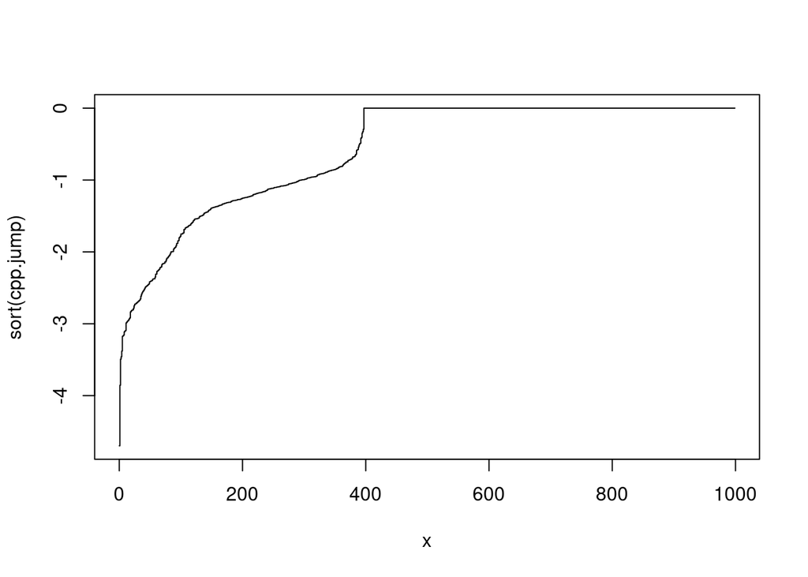

```r
plot(x,sort(cpp.jump), type="s")
```